# R Notebook

```r
library(tidyverse)
```

```r
revenue <- CodeClanData::qb_revenue_breakdown %>% janitor::clean_names()
monthly_sales <- CodeClanData::qb_monthly_sales %>% janitor::clean_names()
competitors <- CodeClanData::qb_competitors %>% janitor::clean_names()
device <- CodeClanData::qb_device_data %>% janitor::clean_names()
```

# Question 1.

Take the data in the dataset `qb_revenue_breakdown` and make a stacked bar chart showing the sources of revenue across the two years in the dataset.

Revenue has three columns, “product”, “year” and “revenue”;

```r
col_scheme <- c("#E89FE9", "#50434F", "#B6A7B5", "#F9A472", "#BD7040")

scale_fill_manual(col_scheme)
```

[output not shown]

```r
scale_color_manual(col_scheme)
```

[output not shown]

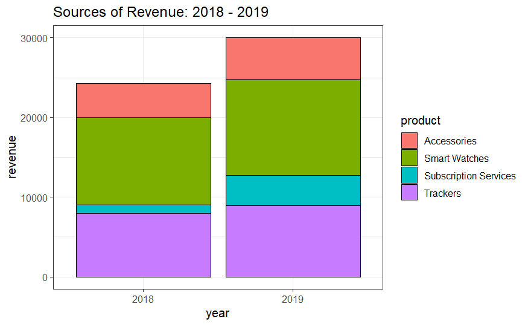

```r
revenue %>%
  ggplot() +
  aes(x = year, y = revenue, fill = product) +
  geom_col(colour = "black") +
  labs(title = "Sources of Revenue: 2018 - 2019") +
  theme_bw(base_size = 12)
```

# Question 2.

Make a line chart showing monthly sales of the “flagship product” - the ‘KwikBit Unit 1’ - over the last year. This data is inside `qb_monthly_sales`, but you will need to use filter() or subset() (base R).

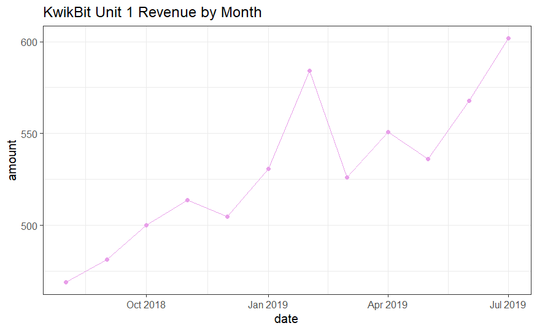

```r
kwikbit_sales <- monthly_sales %>%
  filter(cashflow == "Kwikbit Unit 1 Sales") %>%
  group_by(date) %>%
  summarise(amount)

ggplot(kwikbit_sales) +
  aes(x = date, y = amount) +
  geom_line(colour = "#E89FE9") +
  geom_point(aes(x = date, y = amount), colour = "#E89FE9") +
  labs(title = "KwikBit Unit 1 Revenue by Month") +
  theme_bw(base_size = 12)
```

```r
NA
```

# Question 3.

Make a line chart showing monthly revenue and costs over the last year. This data is also in `qb_monthly_sales`

```r
operating_profit <- monthly_sales %>%
  filter(date >= 2018-07-01 & (cashflow == "Cost" | cashflow == "Total Revenue")) %>%
  group_by(cashflow, date) %>%
  summarise(amount)
```

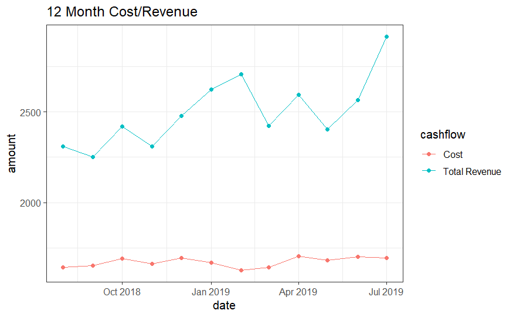

```r
operating_profit %>%
  ggplot() +
  aes(x = date, y = amount, colour = cashflow) +
  geom_line() +
  geom_point(aes(x = date, y = amount)) +
  labs(title = "12 Month Cost/Revenue") +
  theme_bw(base_size = 12)
```

# Question 4.

Show annual sales of personal fitness trackers over the last 5 years broken down by company as a ribbon plot (use geom_area). This data is in qb_competitors.

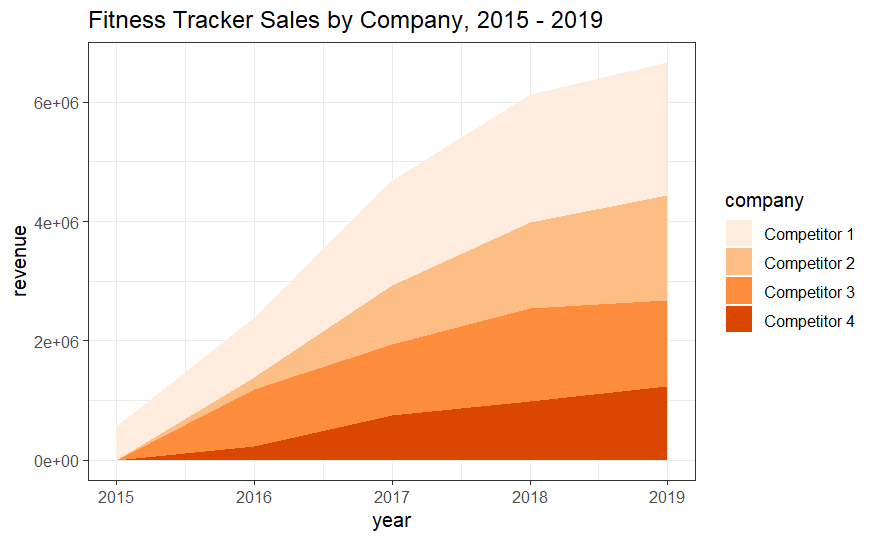

```r
competitors %>%
  ggplot() +
  aes(x = year, y = revenue, fill = company) +
  geom_area() +
  scale_fill_brewer(palette = "Oranges") +
  labs(title = "Fitness Tracker Sales by Company, 2015 - 2019") +
  theme_bw(base_size = 12)
```

# Question 5.

Now show the sales from the four competitors as a line graph. Include an extra layer that shows the data points used to make the lines.

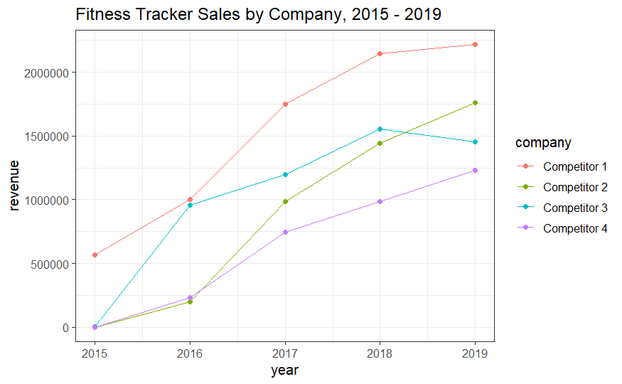

```r
competitors %>%
  ggplot() +
  aes(x = year, y = revenue, colour = company) +
  geom_line() +
  geom_point() +
  scale_fill_brewer(palette = "Set1") +
  labs(title = "Fitness Tracker Sales by Company, 2015 - 2019") +
  theme_bw(base_size = 12)
```

# Question 6.

Now the company wants to compare the number of steps that their device counts vs. their competitors. Make a line graph of the number of steps throughout time, and use faceting to compare between companies and people. The data for this is in `qb_device_data`.

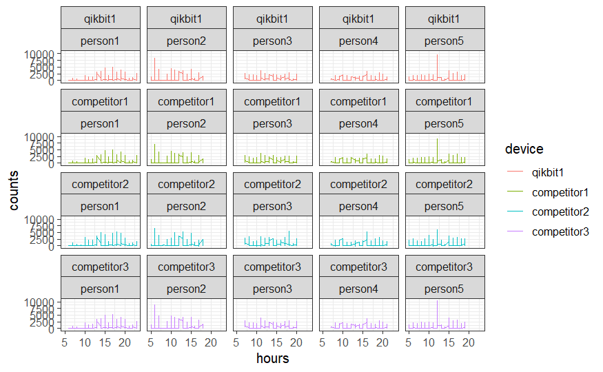

```r
device %>%
  ggplot() +
    aes(x = hours, y = counts, colour = device) +
    geom_line() +
    facet_wrap(device ~ id) +
    theme_bw(base_size = 12)
```

```r
NA
NA
NA
```